# Choosing a Major: Is Money on Your Mind?

Jessica Tran

4/25/2021

### Background

Picking a major is something that is constantly on the minds of high school students, and even college students who may be rethinking their choice. Two opposing mindsets are (1) to choose a major that will allow you to get a good job and earn a steady income, or (2) to choose a major that you are passionate about, even though your financial stability may not be guaranteed. In my experience, the former is most often practiced and agreed with. Both viewpoints are valid, however, do data show that people actually follow the advice of either? To learn more about this, we can use the College Majors dataset that was compiled from the American Community Survey (2010-2012) Public Use Microdata Series by FiveThirtyEight.

In the dataset there are 173 observatons (or rows) representing majors, and there are 21 variables (or columns). The variables included in this dataset describe the major rank by median earnings, major code or identifier, the number of people with the major, the number of men and women with the major, the proportion of women in a major, employment statistics (broken down into full-time, part-time, and year-round), unemployment numbers and rates, the spread of values for earnings, and the jobs people have. As described, this dataset has a load of information! However, to answer our question, we will be focusing on the major and major categories, as well as the total people in the major and the earnings.

The median variable provides the median earnings of full-time, year-round workers that are in a particular major. It is a numeric variable that is measured in U.S. dollars. The total variable in the dataset provides the number of people who have the major. This variable is an integer, and is measured in people. Major_categories is a character variable describing the larger categories that the individual majors fall under, such as engineering. The major variable is also made up of characters, and describes each individual major.

### Data Analysis

Taking a look at the graph below, the four major categories with the highest median earnings are engineering, business, computers & mathematics, and law & public policy. This fits with the general concept that traditional career paths tend to have higher incomes. On the other hand, the four major categories with the lowest median earnings are psychology & social work, humanities & liberal arts, education, and arts. Similarly, these categories align with less traditional, higher-risk career paths.

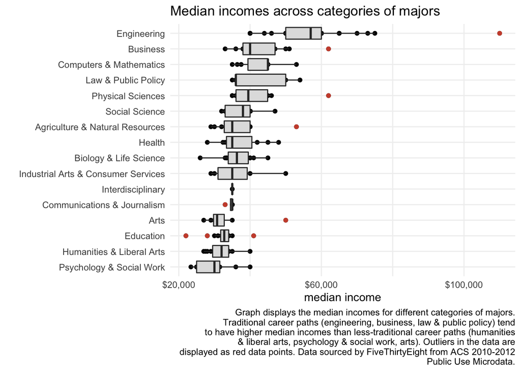

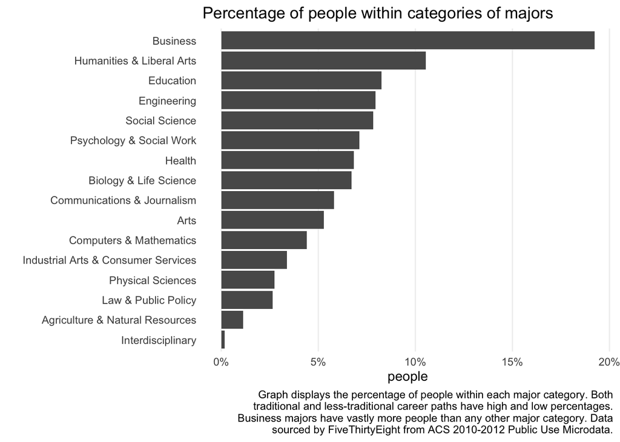

In the graph above, we can see the percentage of people within each major category. The percent was calculated by dividing the total number of people in each major category by the sum of the total people for every major category. The top four categories with the most people are business, humanities & liberal arts, education, and engineering. This is curious, because both business and engineering were in the top four major categories for median earnings while education and humanities & liberal arts were in the bottom four categories for median earnings. Does this mean that there are people who value financial stability over passion? Or, are most people passionate about their major choice, and some just happen to be passionate about high-earning majors?

Both the business and the humanities & liberal arts categories had high percentages of people with majors that fell into each respective category. When it comes to earnings, however, the two categories are vastly different; business majors had the second highest median earnings, and humanities & liberal arts majors had the second lowest earnings. The fact that business majors have both high median incomes and a high percentage of people could paint the picture that people do, in fact, prefer to major in areas that are known to result in financially stable careers. However, the results for humanities & liberal arts majors contradicts that picture, so let us take a more in-depth look at the business majors.

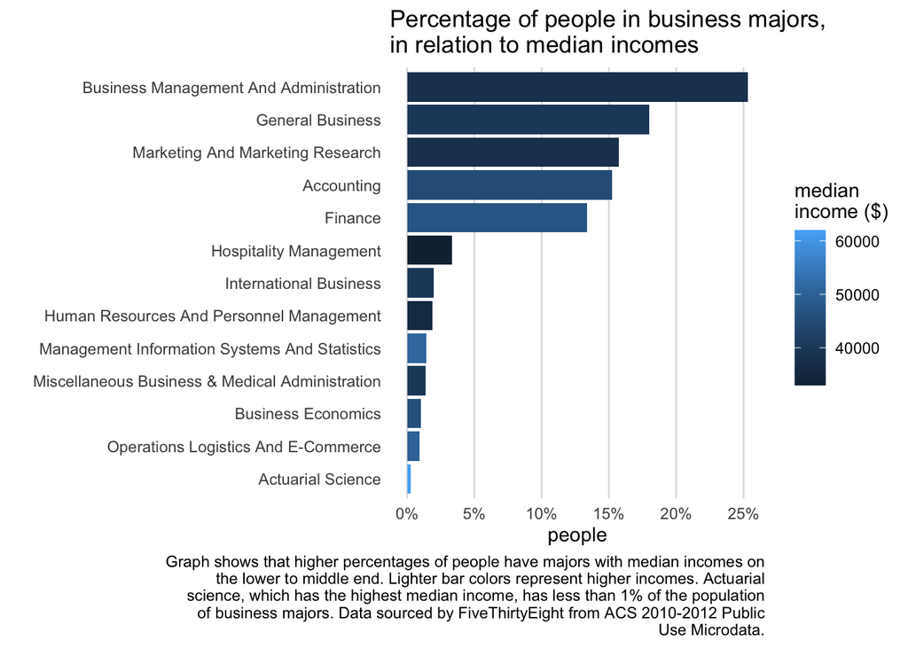

As shown in the graph, the percent of business majors in business management and administration is the highest, while actuarial science has the lowest percentage of people. Actuarial science has the highest median income of all the business majors, with the median earnings being $62,000. Surprisingly, the percentage of business majors within this particular major is less than 1 % - it is 0.29 % to be exact. The majors with higher percentages of people also somewhat err on the middle to lower side of median earnings.

Just focusing on business majors, these results are quite interesting. Given that business majors have high median earnings and a high percentage of people, it is not unreasonable to believe that the two are related in some way. On the other hand, more in-depth analysis shows that very few people actually choose the highest paying major: actuarial science. This could be an indication that money is not an important factor for business majors. Another possibility could be that actuarial science has a higher level of difficulty; while the income is alluring, the actual workload may not be, leading people to choose different majors within the business category that could be easier.

We can also take a closer look at the humanities & liberal arts category; the graph below shows the relationship between the majors, median earnings, and percentage of people within each major. Or rather, it shows the lack of relationship between these variables. There does not seem to be any distinct patterns between income and percentage of people in the major, which continues to show that, within this category, money does not seem to play an important part in choosing one’s major. One thing to note, though, would be the United States history major which has median earnings of $40,000 (the highest median earnings of all the humanities & liberal arts majors). This major also has the lowest percentage of people, with less 0.43 % of the people within the humanities & liberal arts category.

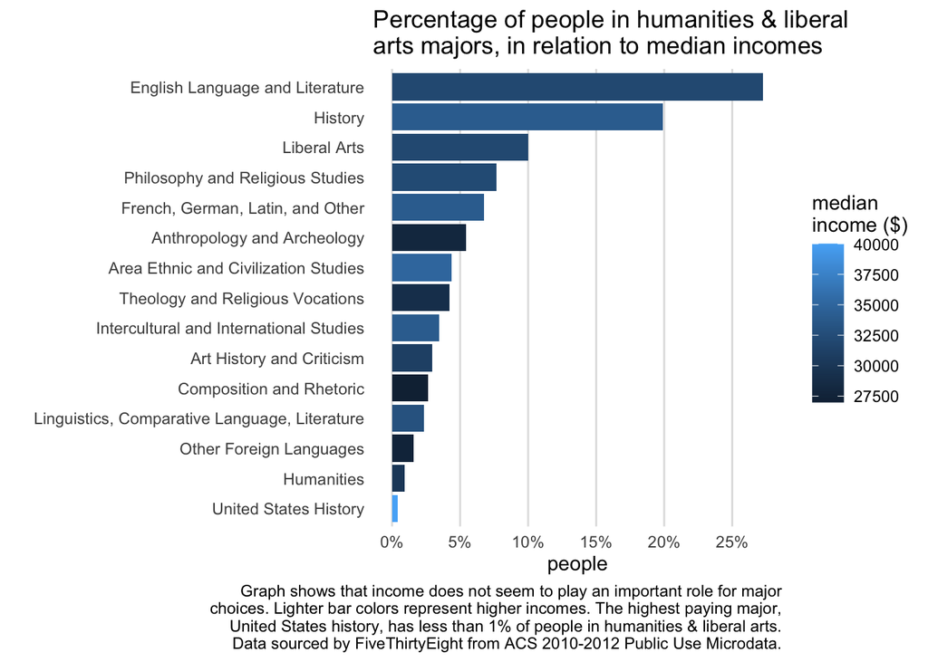

### Conclusion

By analyzing the visualizations and data, it appears as though money does not have a strong influence on what majors people may choose. While the highest paying major categories have high percentages of people, the lowest paying categories do as well. Along with this, within the business and humanities & liberal arts categories, the highest paying majors for each also had the lowest amount of people. Whether this is a result of higher-paying careers being more difficult or a general disinterest in the higher-paying majors, it indicates that, when choosing majors, money is not always on the mind.